# Northern Norways New Companies

Lucas Stark

01 10 2019

# 1 Research Question

The following research was conducted to answer the following question: “How many new companies were registered in Northern Norway per county and month in 2019?”

# 2 Data Source

The data was imported from the website of [Bronnoysundregistrene of Norway](https://w2.brreg.no/kunngjoring/kombisok.jsp?datoFra=01.01.2019&datoTil=30.09.2019&id_region=100&id_fylke=-+-+-&id_niva1=2&id_bransje1=0).

# 3 Data Cleaning

The data was cleaned in two major steps. The first one focused on getting the dataset for each seperate county of Northern Norway, getting rid of chunk lines and joining the datasets again with a new variable for the county name.

The second step focused on selecting the necessary variables and transforming them into the appropriate type.

In summary the structure of the final and cleaned dataset looks like this:

```
## 'data.frame':    2231 obs. of  5 variables:
##  $ county  : Factor w/ 3 levels "Finnmark","Nordland",..: 1 1 1 1 1 1 1 1 1 1 ...
##  $ company : Factor w/ 2239 levels "0-FILTER VLADIMIR JAKOLA",..: 2 8 10 14 23 24 27 28 29 30 ...
##  $ number  : Factor w/ 2236 levels "812 453 742",..: 1675 1119 379 793 1554 1532 86 234 1597 1844 ...
##  $ date    : Date, format: "2019-07-10" "2019-04-27" ...
##  $ ann_type: Factor w/ 2 levels "Nyregistrering i Foretaksregisteret",..: 1 1 1 1 1 1 1 1 1 1 ...
```

# 4 Data Analysis

To find out how many companies have been registered per month and per county the following linegraph was created.

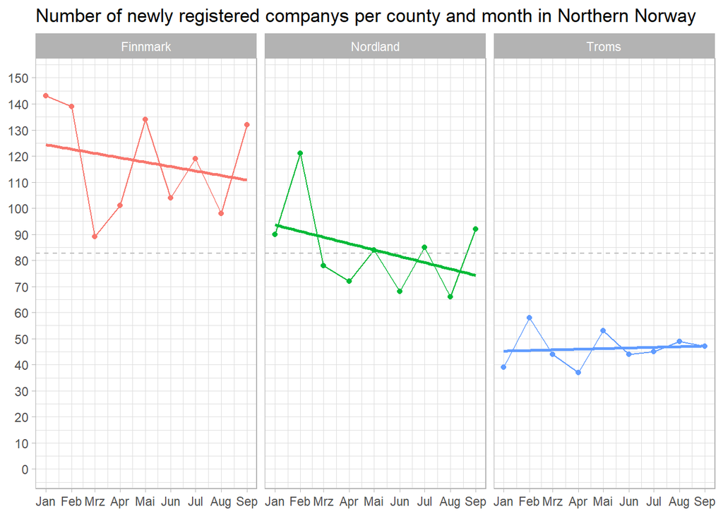

As you can see, in general, most new companies were registered in Finnmark. The overall mean of new registrations per month is 82.63 which is depicted as the dashed line in the graphic. The month with the most new registrations was Februar with an average of 106 new registrations.